# Stat 135: Lab Project

## Question 5:

First let's split our data by the interval specified by Table 1.

```r
res <- 1:359
i = 1
for (bm in data$BMI) {
  if (bm < 18.5) {
    res[i] = 1
  } else if (bm >= 18.5 & bm < 25) {
    res[i] = 2
  } else if (bm >= 25 & bm < 30) {
    res[i] = 3
  } else if (bm >= 30 & bm < 35) {
    res[i] = 4
  } else if (bm >= 35 & bm < 40) {
    res[i] = 5
  } else {
    res[i] = 6
  }
  i = i + 1
}
data$bmicat <- res
bmicat.mat <- matrix(0, 2, 6)

for (i in 1:359) {
  bmicat.mat[as.numeric(data$gender)[i] - 1, data$bmicat[i]] = bmicat.mat[as.numeric(data$gender)[i] - 1, data$bmicat[i]] + 1
}
```

Now, let's run a chi-square test of homogeneity.

```r
chisq.test(bmicat.mat)
```

```r
## Warning in chisq.test(bmicat.mat): Chi-squared approximation may be
## incorrect
```

```r
##
##  Pearson's Chi-squared test
##
## data:  bmicat.mat
## X-squared = 25.3523, df = 5, p-value = 0.0001191
```

Our p-value, 0.0001191, is much less than 0.01. So, our results our very significant and we reject the null hypothesis which states that the distributions of BMI among the genders are the same.

Now let's split our data according to Table 2.

```r
res <- 1:359
i = 1
for (wh in data$WHR) {
  ag = data$age[i]
  if (
      ((data$gender[i] == "male") & ((wh < 0.83 & ag < 30) | (wh < 0.84 & ag < 40 & ag >= 30) | (wh < 0.88 & ag < 50 & ag >= 40) | (wh < 0.90 & ag < 60 & ag >= 50) |(wh < 0.91 & ag >= 60))) |
      ((data$gender[i] == "female") & ((wh < 0.71 & ag < 30) | (wh < 0.72 & ag < 40 & ag >= 30) | (wh < 0.73 & ag < 50 & ag >= 40) | (wh < 0.74 & ag < 60 & ag >= 50) |(wh < 0.76 & ag >= 60)))
    )
  {
    res[i] = 1
  } else if (
      ((data$gender[i] == "male") & ((wh >= 0.83 & wh < 0.89 & ag < 30) | (wh >= 0.84 & wh < 0.92 & ag < 40 & ag >= 30) | (wh >= 0.88 & wh < 0.96 & ag < 50 & ag >= 40) | (wh >= 0.90 & wh < 0.97 & ag < 60 & ag >= 50) |(wh >= 0.91 & wh < 0.99 & ag >= 60))) |
      ((data$gender[i] == "female") & ((wh >= 0.71 & wh < 0.78 & ag < 30) | (wh >= 0.72 & wh < 0.79 & ag < 40 & ag >= 30) | (wh >= 0.73 & wh < 0.80 & ag < 50 & ag >= 40) | (wh >= 0.74 & wh < 0.82 & ag < 60 & ag >= 50) |(wh >= 0.76 & wh < 0.84 & ag >= 60)))
    )
  {
    res[i] = 2
  } else if (
    ((data$gender[i] == "male") & ((wh > 0.94 & ag < 30) | (wh > 0.96 & ag < 40 & ag >= 30) | (wh > 1.00 & ag < 50 & ag >= 40) | (wh < 1.02 & ag < 60 & ag >= 50) |(wh < 1.03 & ag >= 60))) |
    ((data$gender[i] == "female") & ((wh > 0.82 & ag < 30) | (wh > 0.84 & ag < 40 & ag >= 30) | (wh > 0.87 & ag < 50 & ag >= 40) | (wh > 0.88 & ag < 60 & ag >= 50) |(wh > 0.90 & ag >= 60)))
  )
  {
    res[i] = 4
  } else {
    res[i] = 3
  }
  i = i + 1
}
data$whrcat <- res
whrcat.mat <- as.matrix(table(data$gender, data$whrcat)[2:3, ])
```

Now we can run another chi-square test of homogeneity.

```r
chisq.test(whrcat.mat)
```

```r
##
##  Pearson's Chi-squared test
##
## data:  whrcat.mat
## X-squared = 125.1513, df = 3, p-value < 2.2e-16
```

Our p-value, whic is < 2.2e-16, is much less than 0.01. So, our results our very significant and we reject the null hypothesis which states that the distributions of WHR among the genders are the same.

## Question 6:

To test both features, and to see if they interact, let's run a Two-Way ANOVA test.

```r
results = aov(glyhb ~ bmicat * whrcat, data = data)
summary(results)
```

```r
##                Df Sum Sq Mean Sq F value Pr(>F)
## bmicat          1   24.5  24.459   5.427 0.0204 *
## whrcat          1    1.0   0.965   0.214 0.6438
## bmicat:whrcat   1    0.1   0.096   0.021 0.8838
## Residuals     355 1600.0   4.507
## ---
## Signif. codes:  0 '***' 0.001 '**' 0.01 '*' 0.05 '.' 0.1 ' ' 1
```

With a p-value of 0.8838, we fail to reject the null which states that the features do not interact. BMI was significant while WHR was not. BMI is more sensitive to glyhb because it has more variability across the groups.

# Part 5: Regression

## Question 1

First let's create our linear model. The most relevant features we selected were: Stabilized Glucose (stab.glu), Age (age), First Systolic Blood Pressure (bp.1s), Waist to Hip Ratio (WHR), & Body Mass Index (BMI).

```r
lm.yhat = lm(glyhb ~ stab.glu + age + bp.1s + WHR + BMI, data = data)
```

Now let's use the predict function to find our predicted values of glyhb.

```r
features_data = data[ , c("stab.glu", "age", "bp.1s", "WHR", "BMI")]
y_hat = predict(lm.yhat, data = features_data)
```

Let's convert our predictions and our actual glyhb values over to logical vectors. This will help us compute the predicted error rate.

Let's first convert the predicted values.

```r
y_hat_diabetes = c()
y_hat_diabetes[y_hat >= 7] = TRUE
y_hat_diabetes[y_hat < 7] = FALSE
data$y_hat_diabetes = y_hat_diabetes
```

Now let's convert the actual values.

```r
y_actual_diabetes = c()
y_actual_diabetes[glyhb >= 7] = TRUE
y_actual_diabetes[glyhb < 7] = FALSE
data$y_actual_diabetes = y_actual_diabetes
```

Lastly, let's compute our predictive error rate.

```r
error_table = table(y_hat_diabetes, y_actual_diabetes)
error_table
```

```r
##               y_actual_diabetes
## y_hat_diabetes FALSE TRUE
##          FALSE   297   19
##          TRUE      8   35
```

```r
pred_error = (error_table[2, 1] + error_table[1, 2]) / sum(error_table)
pred_error
```

```r
## [1] 0.07520891
```

## Question 2

Let's first compute the False Positives Rate. we can use our error_table variable to easily do this.

```r
false_positive = error_table[2, 1] / sum(error_table[ , 1])
false_positive
```

```r
## [1] 0.02622951
```

Now let's compute the False Negatives Rate.

```r
false_negative = error_table[1, 2] / sum(error_table[ , 2])
false_negative
```

```r
## [1] 0.3518519
```

To modify lambda such that our False Negatives Rate is at most 10%, we need to find the threshold such that P(y_hat <= threshold | glyhb >= 7) <= 0.1. The threshold which fulfills this will be our modified lambda and is simply the 10th quantile.

First let's find the y_hat for the set of people who truly have diabetes.

```r
all = y_hat[glyhb >= 7]
```

Now let's find the 10th quantile of this to find our threshold, and thereby find our new lambda.

```r
lambda_new = quantile(all, probs = 0.1)
lambda_new
```

```r
##      10%
## 5.862622
```

Now let's find our False Positive Rate with this new lambda value.

```r
FPR_new = mean(y_hat[glyhb < 7] >= lambda_new)
FPR_new
```

```r
## [1] 0.1311475
```

Our False Positives Rate now increases. This makes sense. In essense, our False Positive Rate is our Type I error, and our False Negative Rate is our Type II error. When we decreased our False Negative Rate, we were decreasing our Type II Error, which in turn increases our Type I error, which increases our False Positive Rate.

## Question 3

First let's find the features with the largest influence. To do this, we fill first need to put all our features on the same scale, so that large magnitudes across the features all follow the same distribution. We will standardize each feature so that each one follows a N(0,1) distribution.

```r
standard_features = cbind(1, apply(features_data, 2, scale))
```

To test for the largest influence, we will run a t-test testing that each beta coefficient is zero. To do this, we need to first find sigma hat squared.

```r
X = standard_features
Y = glyhb
XTX = t(X)%*%X
XTX.inv = solve(XTX)
RSS = t(Y)%*%Y - t(Y) %*% X %*% XTX.inv %*% t(X) %*%Y
RSS
```

```r
##          [,1]
## [1,] 739.1836
```

```r
n = nrow(data)
p = 6
sigma2.hat = RSS/(n-p)
sigma2.hat
```

```r
##          [,1]
## [1,] 2.094004
```

Now that we have sigma hat squared, we can find the t statistics for each beta hat coefficient.

```r
beta.hat = XTX.inv%*%t(X)%*%Y
beta.hat
```

```r
##               [,1]
##          5.5695265
## stab.glu 1.3965997
## age      0.2743039
## bp.1s    0.0835899
## WHR      0.1031767
## BMI      0.1008851
```

```r
t_stat = c()
for (i in 1:5){
  t_stat[i] = abs(beta.hat[i + 1] - 0)/(sqrt(sigma2.hat * XTX.inv[i + 1, i + 1]))
}
```

Lastly, we can find our p-values for each coefficient.

```r
p_vals = 2*(1 - pt(t_stat, n-p))
p_vals
```

```r
## [1] 0.000000000 0.003033552 0.336520758 0.204955625 0.199432521
```

Our first two features, stab.glu and age, are significant and for each we reject the null which states that that particular feature has no effect. In other words, stab.glu and age are two features that we should absolutely keep in our model!

For the other three features, bp.1s, WHR, & BMI, we fail to reject the null and cannot say that b_feature != 0.

## Question 4

We did not conclude that both ratios interact. If we had, we could use this information to improve our regression. We would do so by using an asterisk instead of a plus sign between BMI and WHR in our lm function, which would add a term to the regression for the interaction effect.

## Question 5

First let's find the residuals.

```r
res = y_hat - glyhb
```

Now let's make our three plots. First let's plot the residuals as a function of stab.glu.

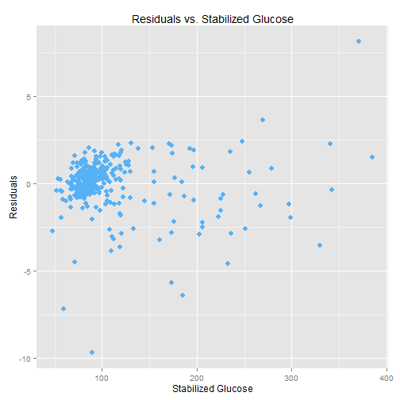

```r
res_data = cbind(res = res, features_data)
ggplot(res_data, aes(x = stab.glu, y = res)) +
    geom_point(shape = 16, col = "#56B1F7", size = 3) +
    xlab("Stabilized Glucose") +
    ylab("Residuals") +
    ggtitle("Residuals vs. Stabilized Glucose")
```

Now let's plot the residuals as a function of BMI.

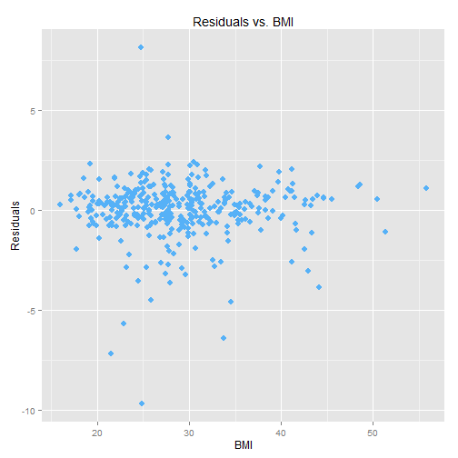

```r
ggplot(res_data, aes(x = BMI, y = res)) +
    geom_point(shape = 16, col = "#56B1F7", size = 3) +
    xlab("BMI") +
    ylab("Residuals") +
    ggtitle("Residuals vs. BMI")
```

Lastly, let's plot the residuals as a function of WHR.

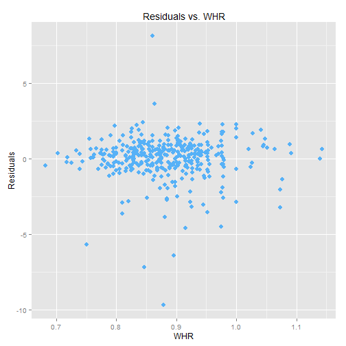

```r
ggplot(res_data, aes(x = WHR, y = res)) +
    geom_point(shape = 16, col = "#56B1F7", size = 3) +
    xlab("WHR") +
    ylab("Residuals") +
    ggtitle("Residuals vs. WHR")
```

For the first residual plot, our residuals seem a bit clustered, but then expand farther away as we move to the right on the x axis.

The second and third residual plots seem to have random scatter, and a somewhat constant variance.

However, maybe a log transformation will help stabilize the variance more and help it become constant.